# Statistica descrittiva

Si illustrano nel seguito alcuni metodi per fare leggere al software di calcolo i dati di cui si vuole ottenere la statistica descrittiva. Il comando “data()” consente di caricare il dataset di interesse nella memoria del software in modo che il software possa accedere ai valori contenuti nel file. Per le opzioni di sintassi di questo comando si usi la scrittura ?data() nella console di R.

```r
data(Resa_estrattiva,package = "Master")
```

Una volta caricato il dataset, è una buona prassi quella di verificare la “classe” del dataset in R, la sua “dimensione” e la sua “struttura”.

```r
class(Resa_estrattiva)
```

```
## [1] "data.frame"
```

```r
dim(Resa_estrattiva)
```

```
## [1] 10  1
```

```r
str(Resa_estrattiva)
```

```
## 'data.frame':    10 obs. of  1 variable:
##  $ Resa: num  13.8 18.8 17.9 23.1 19.3 ...
```

La classe dell’oggetto Resa_estrattiva è quella di dataframe. La sua dimensione è di 10 righe e 1 colonna. La “struttura” del dataframe Resa_estrattiva è quella di una lista di 10 righe (osservazioni) ciascuna caratterizzata da una singola misura (variabile).  
Il formato standard di organizzazione dei dati per le analisi prevede che nelle righe ci siano gli individui (osservazioni, oggetti) e nelle colonne le proprietà o caratteristiche che sono state misurate (variabili, fattori). Il dataset consiste in 10 misure della *Resa estrattiva* di un metodo di isolamento di polifenoli da infusi acquosi di Dittamo cretese (*Origanum dictamus*, meglio noto come *Cretan tea*), una pianta aromatica e medicinale tradizionalmente considerata un rimedio generale per molti disturbi (dalla stanchezza ai disturbi digestivi, alla capacità di agire come disinfettante e cicatrizzante).

```r
Resa_estrattiva
```

|  | Resa |
| --- | --- |
| 1 | 13.84 |
| 2 | 18.77 |
| 3 | 17.85 |
| 4 | 23.05 |
| 5 | 19.27 |
| 6 | 20.87 |
| 7 | 17.35 |
| 8 | 22.37 |
| 9 | 21.45 |
| 10 | 19.40 |

Il pacchetto pastecs permette di ottenere tutti i valori dei descrittori di posizione e dispersione di un gruppo di dati usando un solo comando, nella fattispecie si tratta della funzione stat.desc()

```r
library(pastecs)
stat.desc(Resa_estrattiva)
```

|  | Resa |
| --- | --- |
| nbr.val | 10.0000000 |
| nbr.null | 0.0000000 |
| nbr.na | 0.0000000 |
| min | 13.8400000 |
| max | 23.0500000 |
| range | 9.2100000 |
| sum | 194.2200000 |
| median | 19.3350000 |
| mean | 19.4220000 |
| SE.mean | 0.8591621 |

[output cut: 4 more lines]

Il pacchetto delle funzioni di base di R contiene la funzione summary() che stampa nella console i valori di Minimo (Min.), 1° quartile (1st Qu.), mediana (Median), media (Mean), 3° quartile (3rd Qu.) e massimo (Max.).

```r
summary(Resa_estrattiva$Resa)
```

```
##    Min. 1st Qu.  Median    Mean 3rd Qu.    Max.
##   13.84   18.08   19.34   19.42   21.30   23.05
```

Il pacchetto RcmdrMisc consente invece di fare sia analisi tabellari che grafici dei dati. Usando la funzione numSummary() si ottiene un risultato molto simile a quello descritto per la funzione summary() del pacchetto base di R.

```r
library(RcmdrMisc)
numSummary(data = Resa_estrattiva$Resa)
```

```
##    mean       sd   IQR    0%   25%    50%    75%  100%  n
##  19.422 2.716909 3.225 13.84 18.08 19.335 21.305 23.05 10
```

In questo caso R stampa in console i dati di media (mean), deviazione standard (sd), range interquartile (IQR = differenza tra il terzo ed il primo quartile), distribuzione dei dati ai valori di frequenza % dello 0% (coincidente con il Min.), 25% (equivalente al primo quartile), 50% (equivalente alla mediana), 75% (equivalente al 3° quartile), 100% (coincidente con il Max.).

Un primo strumento grafico di immediata comprensione si ottiene con il comando “plot()” che costruisce il grafico a punti cosiddetto “a dispersione”, per visualizzare i dati così come sono

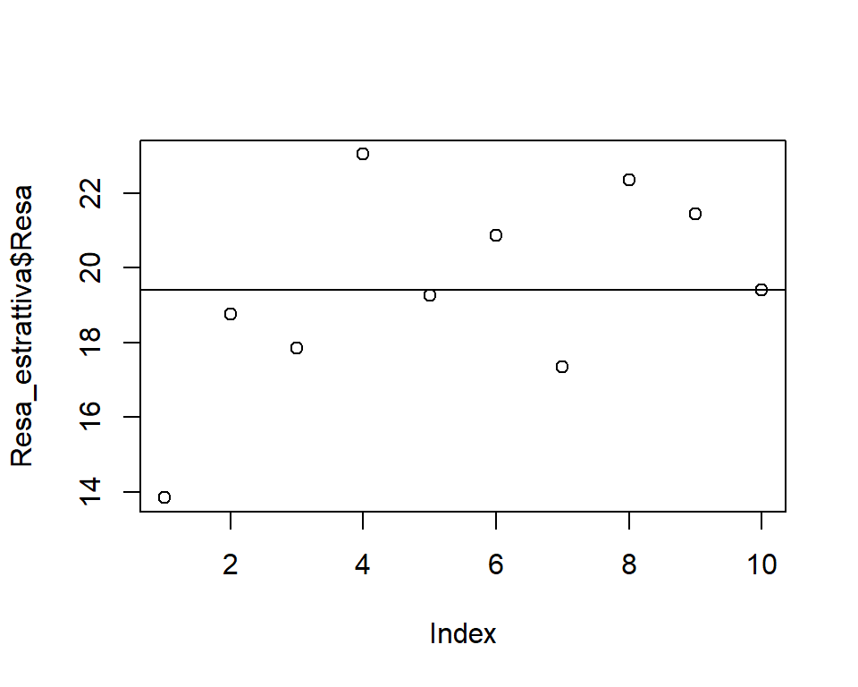

```r
plot(Resa_estrattiva$Resa)
abline(h=mean(Resa_estrattiva$Resa))
```

Il grafico a punti può essere modificato introducendo una quantità di ulteriori elementi, quali ad esempio la linea che mette in evidenzia il valore della media.

Le funzioni grafiche di R sono però praticamente illimitate e chi volesse approfondire gli aspetti della programmazione per la costruzione di grafici può iniziare a guardare l’help della funzione plot(), richiamabile con il comando ?plot(), oppure tutorial specifici e libri gratuiti facilmente reperibili in rete.

Nel pacchetto RcmdrMisc sono contenute funzioni di semplice impiego per stampare grafici a barre

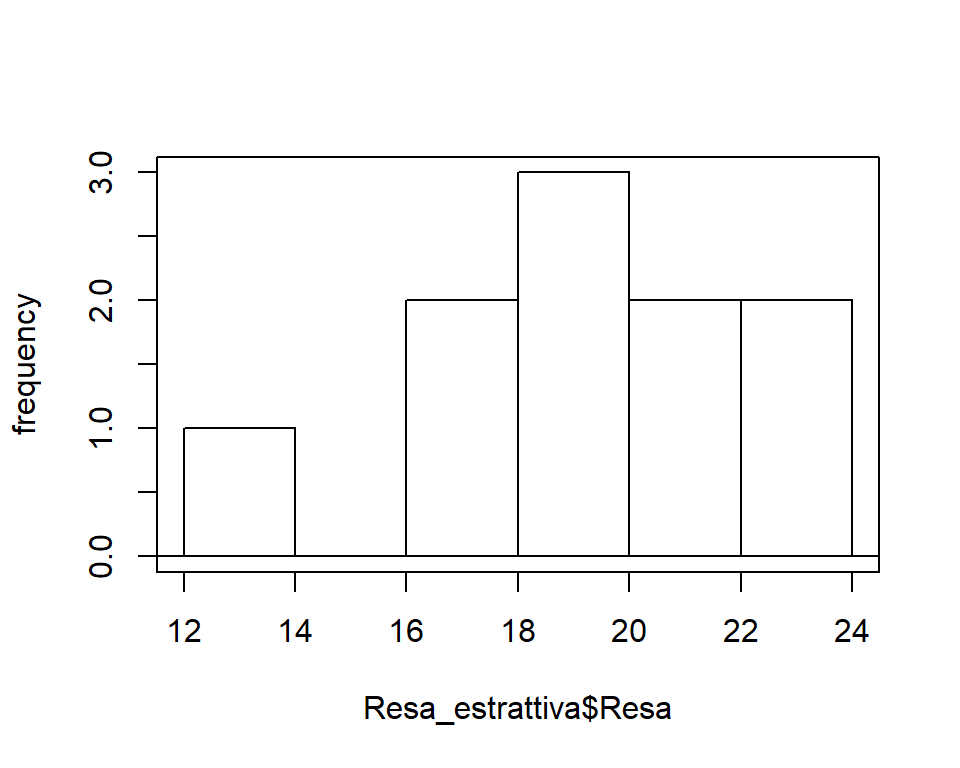

```r
Hist(Resa_estrattiva$Resa,scale = "frequency") # in ordinata qtà
```

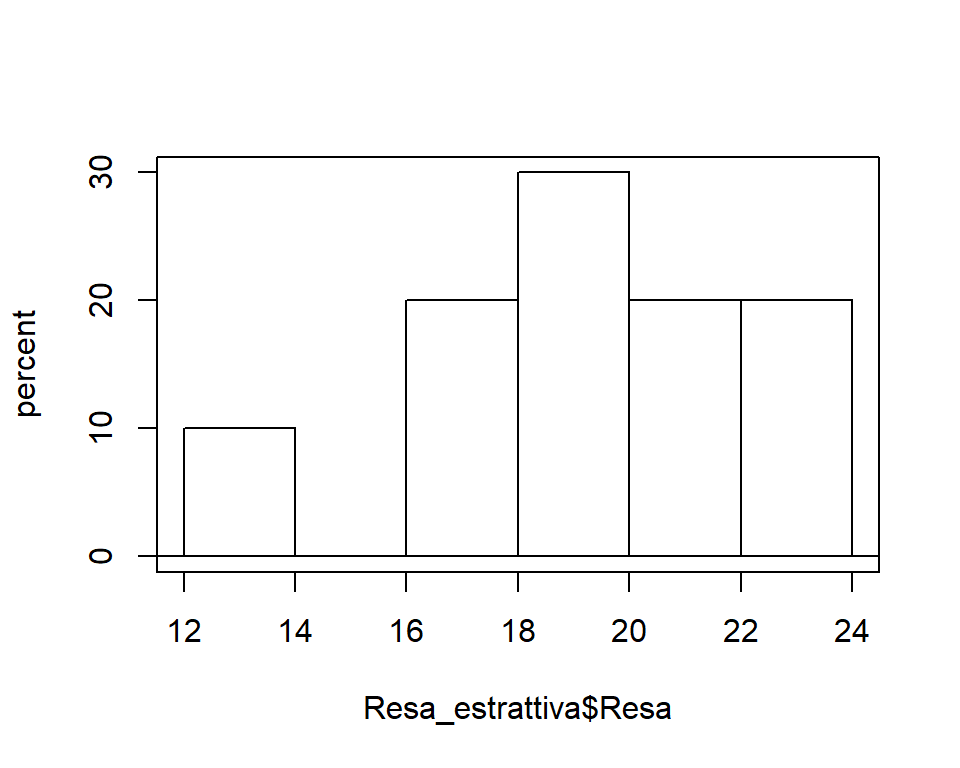

```r
Hist(Resa_estrattiva$Resa,scale = "percent") # in ordinata percentuale rispetto al tot
```

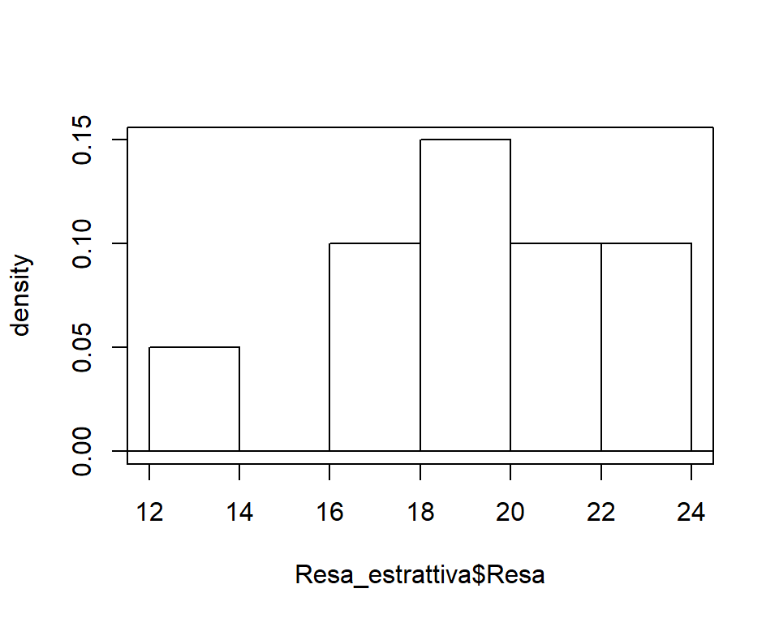

```r
Hist(Resa_estrattiva$Resa,scale = "density") # in ordinata densità: area barra = perc/100
```

oppure grafici del tipo “a punti” o “dot-plot” come quello seguente

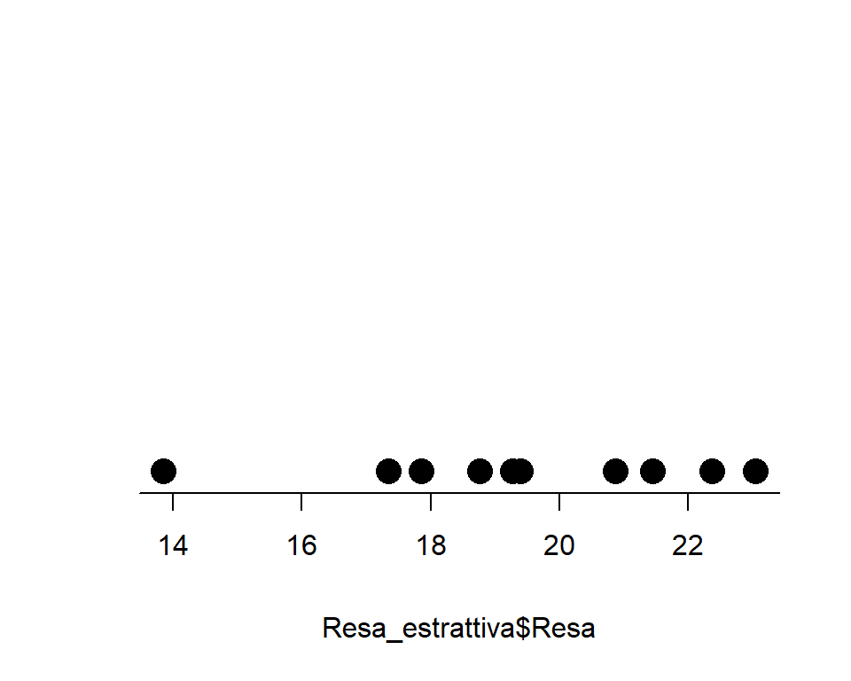

```r
Dotplot(Resa_estrattiva$Resa)
```

Altro importante strumento grafico è il “box-and-whiskers plot” che si ottiene usando la funzione “boxplot()

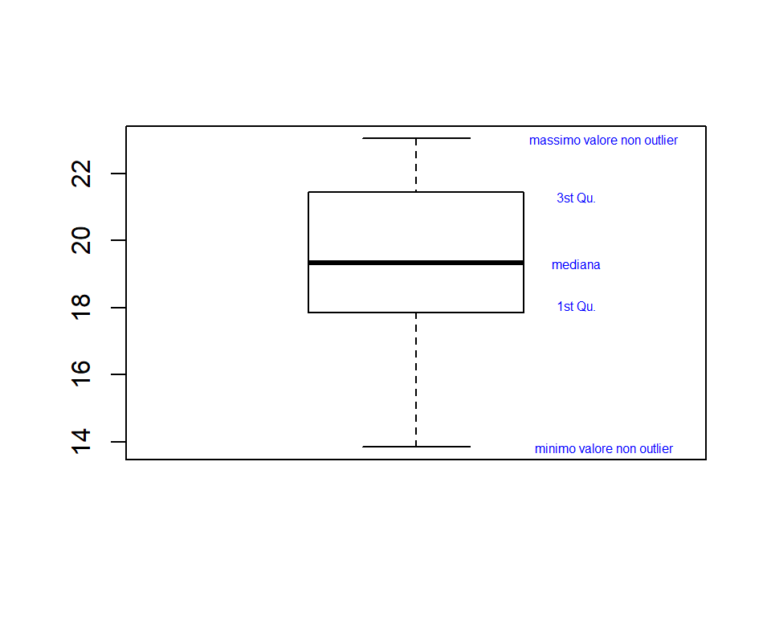

```r
boxplot(Resa_estrattiva$Resa)
text(x = 1.3,y = median(Resa_estrattiva$Resa),label="mediana",col="blue",cex=0.5)
text(x = 1.3,y = quantile(Resa_estrattiva$Resa)[2],label="1st Qu.",col="blue",cex=0.5)
text(x = 1.3,y = quantile(Resa_estrattiva$Resa)[4],label="3st Qu.",col="blue",cex=0.5)
text(x = 1.35,y = min(Resa_estrattiva$Resa),label="minimo valore non outlier",
     col="blue",cex=0.5)
text(x = 1.35,y = max(Resa_estrattiva$Resa),label="massimo valore non outlier",
     col="blue",cex=0.5)
```

Vengono in generale considerati valori anomali (dati aberranti, outliers) i valori che “distano” dai bordi della scatola 1.5 volte la dimensione della scatola. Sono i punti che cadono oltre i baffi (il baffo rappresenta il massimo intervallo contenente i punti non anomali). Si osservi che il valore 1.5 è definito in automatico dalla routine e può essere modificato. Si veda l’help ?boxplot